# Titanic Data Analyses for Survival Chance factors

# Introduction

The titanic data set taken from kaggle data science website, features 891 entries as sample dataset. We will do basic analyses of dataset inculding graphs, function to determine that what are factors in order to know the survival chances of a passengers who boarded the ship.

### Data Dictionary

Variable Definition Key survival Survival 0 = No, 1 = Yes pclass Ticket class 1 = 1st, 2 = 2nd, 3 = 3rd sex Sex  
Age Age in years  
sibsp # of siblings / spouses aboard the Titanic  
parch # of parents / children aboard the Titanic  
ticket Ticket number  
fare Passenger fare  
cabin Cabin number  
embarked Port of Embarkation C = Cherbourg, Q = Queenstown, S = Southampton

### Variable Notes

pclass: A proxy for socio-economic status (SES) 1st = Upper 2nd = Middle 3rd = Lower

age: Age is fractional if less than 1. If the age is estimated, is it in the form of xx.5

sibsp: The dataset defines family relations in this way... Sibling = brother, sister, stepbrother, stepsister Spouse = husband, wife (mistresses and fiancés were ignored)

parch: The dataset defines family relations in this way... Parent = mother, father Child = daughter, son, stepdaughter, stepson Some children travelled only with a nanny, therefore parch=0 for them.

### Data Mining Questions:

1. Does age group increases the survival chances?
2. Does being female or male in in particular age group increases the survival chance?
3. Does passenger class increases the the survival chance?

```python
import pandas as pd
import numpy as np

# Read data
titanic_data = pd.read_csv('titanic_data.csv')
```

```python
titanic_data.head()  # Initail analyses with getting info on data such names and what kind of
                     # values they consist in the dataframe
```

|  | PassengerId | Survived | Pclass | Name | Sex | Age | SibSp | Parch | Ticket | Fare | Cabin | Embarked |
| --- | --- | --- | --- | --- | --- | --- | --- | --- | --- | --- | --- | --- |
| 0 | 1 | 0 | 3 | Braund, Mr. Owen Harris | male | 22.0 | 1 | 0 | A/5 21171 | 7.2500 | NaN | S |
| 1 | 2 | 1 | 1 | Cumings, Mrs. John Bradley (Florence Briggs Th... | female | 38.0 | 1 | 0 | PC 17599 | 71.2833 | C85 | C |
| 2 | 3 | 1 | 3 | Heikkinen, Miss. Laina | female | 26.0 | 0 | 0 | STON/O2. 3101282 | 7.9250 | NaN | S |
| 3 | 4 | 1 | 1 | Futrelle, Mrs. Jacques Heath (Lily May Peel) | female | 35.0 | 1 | 0 | 113803 | 53.1000 | C123 | S |
| 4 | 5 | 0 | 3 | Allen, Mr. William Henry | male | 35.0 | 0 | 0 | 373450 | 8.0500 | NaN | S |

```python
titanic_data.info() # Data set information related to data type and count which gives more insigts about
                    # null values in each variable
```

```
<class 'pandas.core.frame.DataFrame'>
RangeIndex: 891 entries, 0 to 890
Data columns (total 12 columns):
PassengerId    891 non-null int64
Survived       891 non-null int64
Pclass         891 non-null int64
Name           891 non-null object
Sex            891 non-null object
Age            714 non-null float64
SibSp          891 non-null int64
Parch          891 non-null int64
Ticket         891 non-null object
Fare           891 non-null float64
Cabin          204 non-null object
Embarked       889 non-null object
dtypes: float64(2), int64(5), object(5)
memory usage: 83.6+ KB
```

```python
titanic_data.describe() # Describes general statistics of each variable
```

|  | PassengerId | Survived | Pclass | Age | SibSp | Parch | Fare |
| --- | --- | --- | --- | --- | --- | --- | --- |
| count | 891.000000 | 891.000000 | 891.000000 | 714.000000 | 891.000000 | 891.000000 | 891.000000 |
| mean | 446.000000 | 0.383838 | 2.308642 | 29.699118 | 0.523008 | 0.381594 | 32.204208 |
| std | 257.353842 | 0.486592 | 0.836071 | 14.526497 | 1.102743 | 0.806057 | 49.693429 |
| min | 1.000000 | 0.000000 | 1.000000 | 0.420000 | 0.000000 | 0.000000 | 0.000000 |
| 25% | 223.500000 | 0.000000 | 2.000000 | 20.125000 | 0.000000 | 0.000000 | 7.910400 |
| 50% | 446.000000 | 0.000000 | 3.000000 | 28.000000 | 0.000000 | 0.000000 | 14.454200 |
| 75% | 668.500000 | 1.000000 | 3.000000 | 38.000000 | 1.000000 | 0.000000 | 31.000000 |
| max | 891.000000 | 1.000000 | 3.000000 | 80.000000 | 8.000000 | 6.000000 | 512.329200 |

Max age is 80 years, and minimum age is .42 years. Simlarly max fare is 512.32, and minimum fare is 0.00.

# Data Cleaning

Below is the Number of passengers boarded the ship from each Emabrked point in the given sample data set

```python
Count_Embarked = titanic_data.groupby('Embarked').size()
Count_Embarked
```

```
Embarked
C    168
Q     77
S    644
dtype: int64
```

It is clear that most of the passengers had departed from SouthHampton which is denoted by 'S' in the data set. Therefore, we can make assumption that null entries in the Embarked field can be replaced with SouthHampton with the dontion 'S'.

```python
titanic_data['Embarked'] = titanic_data.Embarked.replace(np.NaN, 'S')
Count_Embarked = titanic_data.groupby('Embarked').size()
Count_Embarked
```

```
Embarked
C    168
Q     77
S    646
dtype: int64
```

In order to have a more clear idea that which age group has more chaces of survival, I would like to do Binning Age and creating a new column with age_group

```python
bins = [0,10,20,30,40,50,60,70,80,90,100]
age_labels = ['Kid', 'Teen', '20s', '30s', '40s', '50s','60s','70s','80s','90s']
titanic_data['age_group'] = pd.cut(titanic_data.Age, bins, right=False, labels=age_labels)

titanic_data.head()
```

|  | PassengerId | Survived | Pclass | Name | Sex | Age | SibSp | Parch | Ticket | Fare | Cabin | Embarked | age_group |
| --- | --- | --- | --- | --- | --- | --- | --- | --- | --- | --- | --- | --- | --- |
| 0 | 1 | 0 | 3 | Braund, Mr. Owen Harris | male | 22.0 | 1 | 0 | A/5 21171 | 7.2500 | NaN | S | 20s |
| 1 | 2 | 1 | 1 | Cumings, Mrs. John Bradley (Florence Briggs Th... | female | 38.0 | 1 | 0 | PC 17599 | 71.2833 | C85 | C | 30s |
| 2 | 3 | 1 | 3 | Heikkinen, Miss. Laina | female | 26.0 | 0 | 0 | STON/O2. 3101282 | 7.9250 | NaN | S | 20s |
| 3 | 4 | 1 | 1 | Futrelle, Mrs. Jacques Heath (Lily May Peel) | female | 35.0 | 1 | 0 | 113803 | 53.1000 | C123 | S | 30s |
| 4 | 5 | 0 | 3 | Allen, Mr. William Henry | male | 35.0 | 0 | 0 | 373450 | 8.0500 | NaN | S | 30s |

```python
titanic_data_survivors_before_cleaning = titanic_data.groupby('Survived').get_group(1)

titaninc_data_non_survivors_before_cleaning = titanic_data.groupby('Survived').get_group(0)
```

```python
age_group_survivors_before_cleaning = titanic_data_survivors_before_cleaning.groupby('age_group').size()
```

```python
age_group_non_survivors_before_cleaning = titaninc_data_non_survivors_before_cleaning.groupby('age_group').size()
```

As most common method to impute null values is replacing with mean value, therefore here I have replaced age null values with the mean of Age. However, this will affect the result as all the age values which are null, will be replaced with one age group. The best case scenario would be if I could predict age as well and replacing values with the predicted age, this will be the work in future as I am not aware of machine learning techniques.

```python
age_mean = titanic_data['Age'].mean()
print(age_mean)
titanic_data['Age'] = titanic_data.Age.replace(np.NaN, age_mean)
titanic_data['age_group'] = titanic_data.age_group.replace(np.NaN, '20s')

titanic_data.info()
```

```
29.69911764705882
<class 'pandas.core.frame.DataFrame'>
RangeIndex: 891 entries, 0 to 890
Data columns (total 13 columns):
PassengerId    891 non-null int64
Survived       891 non-null int64
Pclass         891 non-null int64
Name           891 non-null object
Sex            891 non-null object
Age            891 non-null float64
SibSp          891 non-null int64
Parch          891 non-null int64
Ticket         891 non-null object
Fare           891 non-null float64
Cabin          204 non-null object
Embarked       891 non-null object
age_group      891 non-null category
dtypes: category(1), float64(2), int64(5), object(5)
memory usage: 84.6+ KB
```

```python
#remove unwanted column
titanic_data_new = titanic_data.drop(['PassengerId','Name','Cabin'],1)
titanic_data_new.head()
```

|  | Survived | Pclass | Sex | Age | SibSp | Parch | Ticket | Fare | Embarked | age_group |
| --- | --- | --- | --- | --- | --- | --- | --- | --- | --- | --- |
| 0 | 0 | 3 | male | 22.0 | 1 | 0 | A/5 21171 | 7.2500 | S | 20s |
| 1 | 1 | 1 | female | 38.0 | 1 | 0 | PC 17599 | 71.2833 | C | 30s |
| 2 | 1 | 3 | female | 26.0 | 0 | 0 | STON/O2. 3101282 | 7.9250 | S | 20s |
| 3 | 1 | 1 | female | 35.0 | 1 | 0 | 113803 | 53.1000 | S | 30s |
| 4 | 0 | 3 | male | 35.0 | 0 | 0 | 373450 | 8.0500 | S | 30s |

# Data Exploration

### Grouping titanic sample data frame in Survivors and Non Survivors

```python
## Grouping survivors and non survivors passengers in two variables
titanic_data_survivors_after_cleaning = titanic_data_new.groupby('Survived').get_group(1)

titanic_data_non_survivors_after_cleaning = titanic_data_new.groupby('Survived').get_group(0)
```

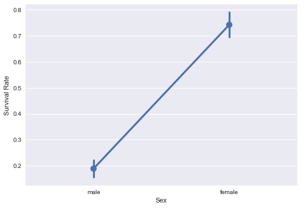

```python
sns.pointplot(x='Sex', y='Survived', data=titanic_data_new);
plt.ylabel('Survival Rate')
plt.show()
```

The above chart shows that survival rate of female gender is much higher than male gender in general.

```python
age_group_survivors_after_cleaning = titanic_data_survivors_after_cleaning.groupby('age_group').size()
age_group_non_survivors_after_cleaning = titanic_data_non_survivors_after_cleaning.groupby('age_group').size()
```

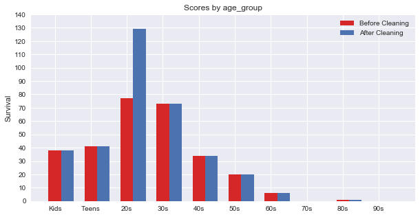

```python
# Plotting survivors by age group

import matplotlib.pyplot as plt
%pylab inline
import seaborn as  sns

plt.figure(figsize=(10,5))

N = 10
index = np.arange(N)    # the x locations for the groups
width = 0.35       # the width of the bars: can also be len(x) sequence

p1 = plt.bar(index, age_group_survivors_before_cleaning, width, color='#d62728')
p2 = plt.bar(index+width, age_group_survivors_after_cleaning, width)

plt.ylabel('Survival')
plt.title('Scores by age_group')
plt.xticks(index, ('Kids', 'Teens', '20s', '30s', '40s','50s','60s','70s','80s','90s','100s'))
plt.yticks(np.arange(0, 141, 10))
plt.legend((p1[0], p2[0]), ('Before Cleaning', 'After Cleaning'))



plt.show()
```

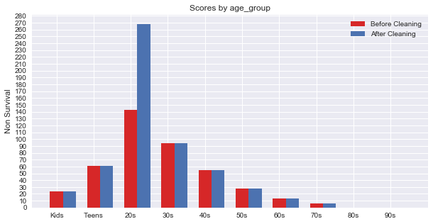

```python
# Plotting Non Survivors by age group

plt.figure(figsize=(10,5))

N = 10
index = np.arange(N)    # the x locations for the groups
width = 0.35       # the width of the bars: can also be len(x) sequence

p1 = plt.bar(index, age_group_non_survivors_before_cleaning, width, color='#d62728')
p2 = plt.bar(index+width, age_group_non_survivors_after_cleaning, width)

plt.ylabel('Non Survival')
plt.title('Scores by age_group')
plt.xticks(index, ('Kids', 'Teens', '20s', '30s', '40s','50s','60s','70s','80s','90s','100s'))
plt.yticks(np.arange(0, 281, 10))
plt.legend((p1[0], p2[0]), ('Before Cleaning', 'After Cleaning'))



plt.show()
```

We can see that count of survivors and non survivors, both have increased in age group 20s as we replaced null entries in age with 20s. However, the count of 20s age group was already higher than the other age group in non survivors dataset. The count before cleaning with 20s and 30s were almost same, whereas after cleaning and replacing value with the mean age widened the gap between 20s and 30s age group. We have to assume that replacing age with mean age for null entries wouldn't affect our analysis.

The next step includes surviviors and non survivors by age group to determine if there is any impact on survival rate due to the age group.

```python
## Calculating percent of survivors and non survivors age group
titanic_data_survivors_age_group = titanic_data_survivors_after_cleaning.groupby('age_group').size()
titanic_data_non_survivors_age_group = titanic_data_non_survivors_after_cleaning.groupby('age_group').size()


total_survivors_age_group = titanic_data_survivors_age_group + titanic_data_non_survivors_age_group
percent_survivor_age_group = (titanic_data_survivors_age_group*1.0/total_survivors_age_group)*100
percent_non_survivor_age_group = (titanic_data_non_survivors_age_group*1.0/total_survivors_age_group)*100
```

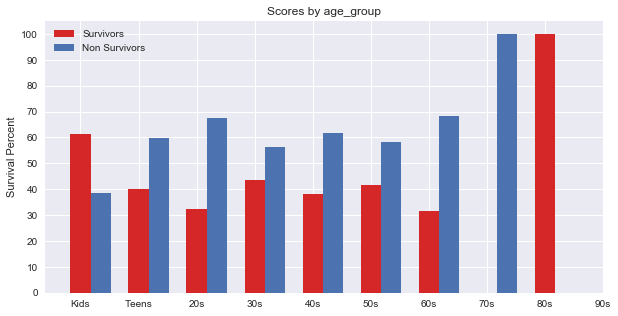

```python
plt.figure(figsize=(10,5))

N = 10
index = np.arange(N)    # the x locations for the groups
width = 0.35       # the width of the bars: can also be len(x) sequence

p1 = plt.bar(index, percent_survivor_age_group, width, color='#d62728')
p2 = plt.bar(index+width, percent_non_survivor_age_group, width)

plt.ylabel('Survival Percent')
plt.title('Scores by age_group')
plt.xticks(index, ('Kids', 'Teens', '20s', '30s', '40s','50s','60s','70s','80s','90s','100s'))
plt.yticks(np.arange(0, 101, 10))
plt.legend((p1[0], p2[0]), ('Survivors', 'Non Survivors'))



plt.show()
```

```python
print(titanic_data_survivors_age_group)
print(titanic_data_non_survivors_age_group)
```

```
age_group
Kid      38
Teen     41
20s     129
30s      73
40s      34
50s      20
60s       6
70s       0
80s       1
90s       0
dtype: int64
age_group
Kid      24
Teen     61
20s     268
30s      94
40s      55
50s      28
60s      13
70s       6
80s       0
90s       0
dtype: int64
```

In this sample dataset 80s group has only one passenger in survivors group and zero passengers in non survivors.Whereas 70s age group has zero percent survival rate.Therefore,we can not determine that whether old age people had more help or people who cannot be saved were not able reach to lifeboats available. Or, it can be assumed they let young people go first because of thier age. Age group 20s has most numbers in survival and non survival data, which can be explained as we replaced null age values with mean age in our original dataset.

Grouping sample data frame of survivors and non survivors by Gender

```python
titanic_data_survivors_female = titanic_data_survivors_after_cleaning.groupby('Sex').get_group('female')
titanic_data_survivors_male = titanic_data_survivors_after_cleaning.groupby('Sex').get_group('male')
titanic_data_non_survivors_female = titanic_data_non_survivors_after_cleaning.groupby('Sex').get_group('female')
titanic_data_non_survivors_male = titanic_data_non_survivors_after_cleaning.groupby('Sex').get_group('male')

survivors_female_age_group = titanic_data_survivors_female.groupby('age_group').size()
survivors_male_age_group = titanic_data_survivors_male.groupby('age_group').size()
non_survivors_female_age_group = titanic_data_non_survivors_female.groupby('age_group').size()
non_survivors_male_age_group = titanic_data_non_survivors_male.groupby('age_group').size()

total_survivors_age_group = survivors_female_age_group + survivors_male_age_group
percent_female_age_group = (survivors_female_age_group*1.0/total_survivors_age_group)*100

percent_male_age_group = (survivors_male_age_group*1.0/total_survivors_age_group)*100
```

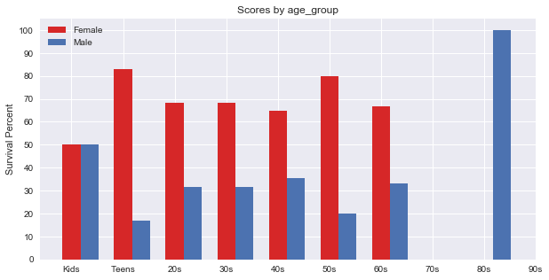

```python
plt.figure(figsize=(10,5))

N = 10
index = np.arange(N)    # the x locations for the groups
width = 0.35       # the width of the bars: can also be len(x) sequence

p1 = plt.bar(index, percent_female_age_group, width, color='#d62728')
p2 = plt.bar(index+width, percent_male_age_group, width)

plt.ylabel('Survival Percent')
plt.title('Scores by age_group')
plt.xticks(index, ('Kids', 'Teens', '20s', '30s', '40s','50s','60s','70s','80s','90s','100s'))
plt.yticks(np.arange(0, 101, 10))
plt.legend((p1[0], p2[0]), ('Female', 'Male'))



plt.show()
```

## Grouping sample frame of survivors and non survivors by Passenger Class

```python
titanic_data_survivors_Pclass = titanic_data_survivors_after_cleaning.groupby('Pclass').size()
titanic_data_non_survivors_Pclass = titanic_data_non_survivors_after_cleaning.groupby('Pclass').size()


total_passengers_Pclass = titanic_data_survivors_Pclass +titanic_data_non_survivors_Pclass
percent_survivors_Pclass = (titanic_data_survivors_Pclass*1.0/total_passengers_Pclass)*100
percent_non_survivors_Pclass = (titanic_data_non_survivors_Pclass*1.0/total_passengers_Pclass)*100

print('Average data for Survivors by Passenger Class')
print(titanic_data_survivors_after_cleaning.groupby('Pclass').mean())
```

```
Average data for Survivors by Passenger Class
        Survived        Age     SibSp     Parch       Fare
Pclass
1            1.0  34.784615  0.492647  0.389706  95.608029
2            1.0  26.076166  0.494253  0.643678  22.055700
3            1.0  23.232689  0.436975  0.420168  13.694887
```

```python
print('Average data for Non Survivors by Passenger Class')
print(titanic_data_non_survivors_after_cleaning.groupby('Pclass').mean())
```

```
Average data for Non Survivors by Passenger Class
        Survived        Age     SibSp     Parch       Fare
Pclass
1            0.0  40.896074  0.287500  0.300000  64.684008
2            0.0  33.266947  0.319588  0.144330  19.412328
3            0.0  27.417500  0.672043  0.384409  13.669364
```

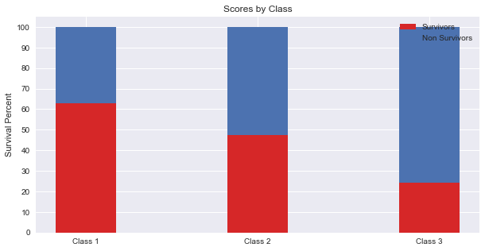

```python
plt.figure(figsize=(10,5))

N = 3
index = np.arange(N)    # the x locations for the groups
width = 0.35       # the width of the bars: can also be len(x) sequence

p1 = plt.bar(index, percent_survivors_Pclass, width, color='#d62728')
p2 = plt.bar(index, percent_non_survivors_Pclass, width,bottom=percent_survivors_Pclass
             )

plt.ylabel('Survival Percent')
plt.title('Scores by Class')
plt.xticks(index, ('Class 1', 'Class 2', 'Class 3'))
plt.yticks(np.arange(0, 101, 10))
plt.legend((p1[0], p2[0]), ('Survivors', 'Non Survivors'))



plt.show()
```

Looking at the above graph, it is clear that class 1 passengers had more chances of survivals.

# Conclusion

# Limitations

I have imputed null values for age with the mean value of age which sort of represent limitations, because it increases 20s age group count dramatically. Therefore, all the results are presented in percent form so that increase in count of passengers in 20s group won't affect conclusion dramatically.

## References:

1. https://stackoverflow.com/questions/31726643/how-do-i-get-multiple-subplots-in-matplotlib
2. https://www.kaggle.com/c/titanic/data
3. http://matplotlib.org/examples/pylab_examples/bar_stacked.html
4. http://pandas.pydata.org/pandas-docs/version/0.15.0/visualization.html#bar-plots
5. https://en.wikipedia.org/wiki/Women_and_children_first